# Lecture 8 Ensemble Learning

Seema Singh Saharan

28 Sept 2019

**Objective:**

- Ameliorating the overall performance by Ensembles: Bagging, Boosting and and Stacking.
- Ensemble are proven to generate better predictions and classification than individual models.
- Ensemble are less interpertable and therefore the insights might not translate to effective decisions. it is hard to decide upon the combination of ML learners to be used together.

# Ensemble Models

- These models are created by integrating two or more weak or strong base learners with the objective of generating a final robust model that provides a classification or prediction by incorporating the information from all base learners.
- This methodology alleviates the bias observed for any individual model.
- Additional to Ensemble method implementation it is important to tune parameters(Example: Number of trees),choose the metric(Example:Accuracy) and the test algorithm (Example:Random Forest) to find the optimal global maxima. It is also paramount to use techniques like crossvalidation to stop overfitting of the data.

# Types of Ensemble Models

1. **Averaging**
- The final prediction is obtained by averaging the values of the models like Regression as well as averaging of probabilities.

| Model 1 | Model 2 | Model 3 | Average Prediction |
| --- | --- | --- | --- |
| 20 | 40 | 60 | 40 |

2. **Majority Voting**
- The final classification of the ML problem can be obtained by majority vote.

| Model 1 | Model 2 | Model 3 | Voting Prediction |
| --- | --- | --- | --- |
| 1 | 0 | 1 | 1 |

3. **Weighted Averaging**
- Individual models are assigned different weightage as per their robustness and the final prediction is obtained by calculating weighted average value.

| Model 1 | Model 2 | Model 3 | Weighted Average Prediction |
| --- | --- | --- | --- |
| .35 | .25 | .40 |  |
| 60 | 70 | 40 | 54.5 |

# Ensemble Implementation Techniques

1. **Bagging**
- Bagging or Bootstrap aggregation implements boot strap sampling to generate training samples.
- The bootstrap samples are for each ML learner is created by sampling with replacement for each learner.
- The samples are individually run through a particular ML algorithms and finally the model classification is decided by the majority vote or averaging for the objective of prediction.
- This technique is very beneficial for scenarios where the algorithm is unstable in context to small changes in the input data.
- Trees have a propensity of being very sensitive to the input data therefore ensemble can be effectively used in this context.
- Random Forest in conjunction with implementing the bootstrap scheme selects a random number of features used as split criterion. This startegy helps further decrease the variance.
- Ipred and caret package provides the bagging implementation.

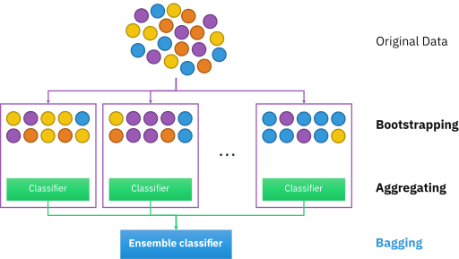

2. **Boosting**
- Boosting like bagging generates resampled samples but it is used to create complementary learners (can be more than two)and higher voting weightage is attributed to the learners that a better prior performance.
- This algorithm entails training the first model using the entire data and then directing the residual from the first learner progressively into the the other learners in order to improve prediction incrementally. Every step gives more weightage to observations that were poorly predicted.
- This algorithm is focused on alleviating the bias within the system though to avoid overfitting the data parameter tuning is important.
- The examples of Boosting is XBoost,GBM,Adaboost.
- This mechanism ensures that weak learners perform as well as the strong learner if not better.
- AdaBoost is a tree based Boosting technique.
- This is considered to be a very innovative and novel discovery in contemporary times.

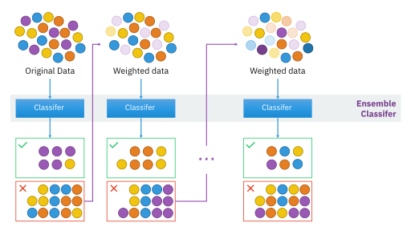

3.**Stacking**

- This ensemble technique implements a layered approach where the intial level has a set of algorithms that generate predictions that are fed into the next level of algorithms that improve these and provide the final predictions.The final level can also use other methods like Averaging,Majority Voting or Weighted Averaging.
- The considerations for choosing models used within the same level are a prediction accuracy threshold and the disparate model predictions are uncorrelated.

https://towardsdatascience.com/ensemble-methods-bagging-boosting-and-stacking-c9214a10a205

# Ensemble R Implementation: Random Forest

```r
library(caret)
library(glmnet)
library(xgboost)
library(randomForest)

library(SuperLearner)

#Available wrappers for prediction and screening the algorithms
listWrappers()
```

```
##  [1] "SL.bartMachine"      "SL.bayesglm"         "SL.biglasso"
##  [4] "SL.caret"            "SL.caret.rpart"      "SL.cforest"
##  [7] "SL.earth"            "SL.extraTrees"       "SL.gam"
## [10] "SL.gbm"              "SL.glm"              "SL.glm.interaction"
## [13] "SL.glmnet"           "SL.ipredbagg"        "SL.kernelKnn"
## [16] "SL.knn"              "SL.ksvm"             "SL.lda"
## [19] "SL.leekasso"         "SL.lm"               "SL.loess"
## [22] "SL.logreg"           "SL.mean"             "SL.nnet"
## [25] "SL.nnls"             "SL.polymars"         "SL.qda"
## [28] "SL.randomForest"     "SL.ranger"           "SL.ridge"
## [31] "SL.rpart"            "SL.rpartPrune"       "SL.speedglm"
## [34] "SL.speedlm"          "SL.step"             "SL.step.forward"
## [37] "SL.step.interaction" "SL.stepAIC"          "SL.svm"
## [40] "SL.template"         "SL.xgboost"
## [1] "All"
## [1] "screen.corP"           "screen.corRank"        "screen.glmnet"
## [4] "screen.randomForest"   "screen.SIS"            "screen.template"
## [7] "screen.ttest"          "write.screen.template"
```

```r
# Fitting a Single Model through Caret


library(ISLR)
library(caret)
library(readxl)
library(pROC)
library(lattice)
library(ggplot2)
library(dplyr)
library(e1071)
library(corrplot)
library(kknn)
library(ggplot2)
library(multiROC)
library(MLeval)
library(AppliedPredictiveModeling)
library(corrplot)
library(Hmisc)
library(dplyr)
library(quantmod)

library(nnet)
library(caret)
library(NeuralNetTools)

library(mlbench)
library(caretEnsemble)
library(ranger)


setwd('C:\\projects\\MachineLearning')

heartdata<-read_excel("heart.xlsx")


heartdata$Sex<-as.character(heartdata$Sex)
heartdata$ChestPainType<-as.character(heartdata$ChestPainType)
heartdata$FastingBPmorethan120<-as.character(heartdata$FastingBPmorethan120)
heartdata$ExerciseInducedAngina<-as.character(heartdata$ExerciseInducedAngina)
heartdata$Thal<-as.character(heartdata$Thal)
#heartdata$ColoredVessels<-as.character(heartdata$ColoredVessels)
heartdata$HeartAttackRisk<-as.factor(heartdata$HeartAttackRisk)

typeof(heartdata$HeartAttackRisk)
```

```
## [1] "integer"
```

```r
heartdata$RestingElectrographicResults<-as.character(heartdata$RestingElectrographicResults)

set.seed(212)

heartdata_initial<-heartdata[c(1,4,5,8,10,12,14)]

trainIndex <- createDataPartition(heartdata$HeartAttackRisk, p = 0.8, list=FALSE)
subTrain <- heartdata_initial[trainIndex,]
subTest <- heartdata_initial[-trainIndex,]
Train_pred<-heartdata[trainIndex,]$HeartAttackRisk

typeof(Train_pred)
```

```
## [1] "integer"
```

```r
Test_pred<-heartdata[-trainIndex,]$HeartAttackRisk

# Create model with default parameters using 10 fold Cross validation, repeated thrice.
control <- trainControl(method="repeatedcv", number=10, repeats=3)
seed <- 10
metric <- "Accuracy"
set.seed(seed)

# Number of features randomly sampled to be used as a split creiterion.
mtry <- sqrt(ncol(subTrain))

# ntree defines the number of trees within random forest
tunegrid <- expand.grid(.mtry=mtry)
rf_default <- train(HeartAttackRisk~., data=heartdata_initial, method="rf",ntree=100, metric=metric, tuneGrid=tunegrid, trControl=control)
print(rf_default)
```

```
## Random Forest
##
## 303 samples
##   6 predictor
##   2 classes: '0', '1'
##
## No pre-processing
## Resampling: Cross-Validated (10 fold, repeated 3 times)
## Summary of sample sizes: 273, 273, 273, 272, 273, 273, ...
## Resampling results:
##
##   Accuracy   Kappa
##   0.7135101  0.4207947
##
## Tuning parameter 'mtry' was held constant at a value of 2.645751
```

```r
#Predict
predictions<-predict(rf_default, subTest, type = "prob")
predictions<-predict(rf_default, subTest)
confusionMatrix(as.factor(predictions),as.factor(Test_pred))
```

```
## Confusion Matrix and Statistics
##
##           Reference
## Prediction  0  1
##          0 27  0
##          1  0 33
##
##                Accuracy : 1
##                  95% CI : (0.9404, 1)
##     No Information Rate : 0.55
##     P-Value [Acc > NIR] : 2.641e-16
##
##                   Kappa : 1
##
##  Mcnemar's Test P-Value : NA
##
##             Sensitivity : 1.00
##             Specificity : 1.00
##          Pos Pred Value : 1.00
##          Neg Pred Value : 1.00
##              Prevalence : 0.45
##          Detection Rate : 0.45
##    Detection Prevalence : 0.45
##       Balanced Accuracy : 1.00
##
##        'Positive' Class : 0
##
```

```r
# Random Search for ascertaining the number of features(mtry) to be used as a split criterion.
control <- trainControl(method="repeatedcv", number=10, repeats=3, search="random")
set.seed(seed)
mtry <- sqrt(ncol(subTrain))
# tuneLength informs the algorithm to apply the assigned number of default values for the tuning parameter.
rf_random <- train(HeartAttackRisk~., data=heartdata_initial, method="rf", metric=metric, tuneLength=5, trControl=control)
print(rf_random)
```

```
## Random Forest
##
## 303 samples
##   6 predictor
##   2 classes: '0', '1'
##
## No pre-processing
## Resampling: Cross-Validated (10 fold, repeated 3 times)
## Summary of sample sizes: 273, 273, 273, 272, 273, 273, ...
## Resampling results across tuning parameters:
##
##   mtry  Accuracy   Kappa
##   2     0.7357039  0.4662217
##   3     0.7288914  0.4522150
##   4     0.7200309  0.4350981
##   6     0.7167767  0.4284179
##
## Accuracy was used to select the optimal model using the largest value.
## The final value used for the model was mtry = 2.
```

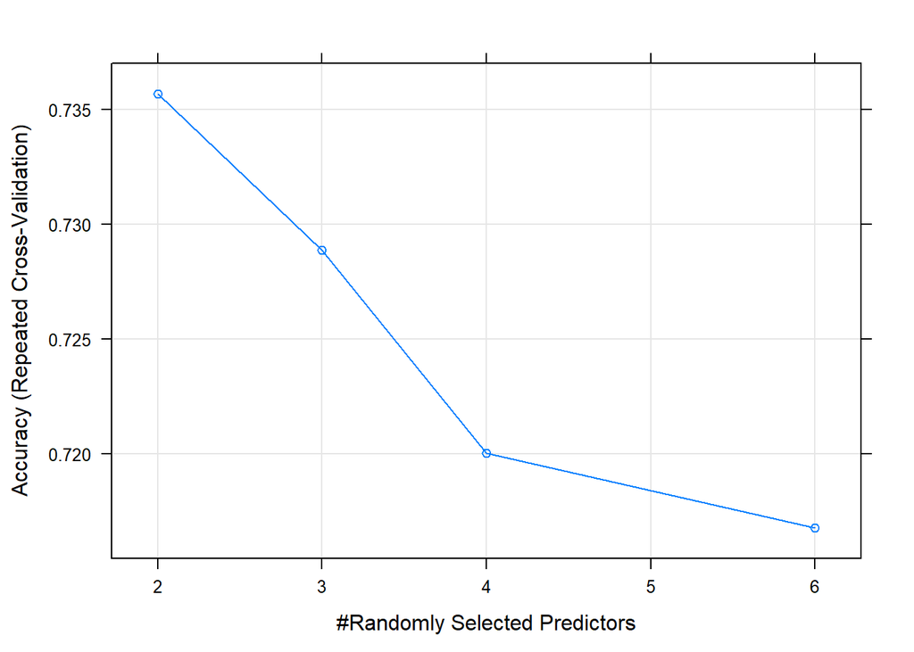

```r
plot(rf_random)
```

```r
#Predict
predict(rf_random, subTest, type = "prob")
```

```
##        0     1
## 1  0.068 0.932
## 2  0.086 0.914
## 3  0.168 0.832
## 4  0.008 0.992
## 5  0.012 0.988
## 6  0.056 0.944
## 7  0.170 0.830
## 8  0.330 0.670
## 9  0.076 0.924
## 10 0.330 0.670
## 11 0.272 0.728
## 12 0.068 0.932
## 13 0.020 0.980
## 14 0.098 0.902
```

[output cut: 46 more lines]

```r
predictions<-predict(rf_random, subTest)
confusionMatrix(as.factor(predictions),as.factor(Test_pred))
```

```
## Confusion Matrix and Statistics
##
##           Reference
## Prediction  0  1
##          0 27  0
##          1  0 33
##
##                Accuracy : 1
##                  95% CI : (0.9404, 1)
##     No Information Rate : 0.55
##     P-Value [Acc > NIR] : 2.641e-16
##
##                   Kappa : 1
##
##  Mcnemar's Test P-Value : NA
##
##             Sensitivity : 1.00
##             Specificity : 1.00
##          Pos Pred Value : 1.00
##          Neg Pred Value : 1.00
##              Prevalence : 0.45
##          Detection Rate : 0.45
##    Detection Prevalence : 0.45
##       Balanced Accuracy : 1.00
##
##        'Positive' Class : 0
##
```

```r
# Grid Search explores a combination of tuning parameters.Here it is the only parameter mtry to be considered.
control <- trainControl(method="repeatedcv", number=10, repeats=3, search="grid")
set.seed(seed)
tunegrid <- expand.grid(.mtry=c(1:15))
rf_gridsearch <- train(HeartAttackRisk~., data=heartdata_initial, method="rf", metric=metric, tuneGrid=tunegrid, trControl=control)
print(rf_gridsearch)
```

```
## Random Forest
##
## 303 samples
##   6 predictor
##   2 classes: '0', '1'
##
## No pre-processing
## Resampling: Cross-Validated (10 fold, repeated 3 times)
## Summary of sample sizes: 273, 273, 273, 272, 273, 273, ...
## Resampling results across tuning parameters:
##
##   mtry  Accuracy   Kappa
##    1    0.7465282  0.4845472
##    2    0.7367458  0.4672563
##    3    0.7234409  0.4417368
##    4    0.7224014  0.4390149
##    5    0.7209986  0.4368152
##    6    0.7188147  0.4323158
##    7    0.7123990  0.4193591
##    8    0.7134384  0.4215305
##    9    0.7167359  0.4281960
##   10    0.7146620  0.4236021
##   11    0.7133284  0.4207103
##   12    0.7122914  0.4191802
##   13    0.7144753  0.4235283
##   14    0.7167717  0.4272218
##   15    0.7146595  0.4244505
##
## Accuracy was used to select the optimal model using the largest value.
## The final value used for the model was mtry = 1.
```

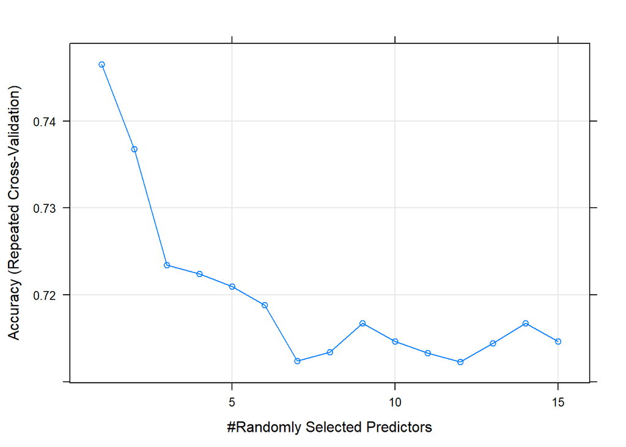

```r
plot(rf_gridsearch)
```

```r
# Predict

predict(rf_gridsearch, subTest, type = "prob")
```

```
##        0     1
## 1  0.056 0.944
## 2  0.082 0.918
## 3  0.178 0.822
## 4  0.006 0.994
## 5  0.008 0.992
## 6  0.054 0.946
## 7  0.176 0.824
## 8  0.366 0.634
## 9  0.090 0.910
## 10 0.348 0.652
## 11 0.246 0.754
## 12 0.102 0.898
## 13 0.020 0.980
## 14 0.074 0.926
```

[output cut: 46 more lines]

```r
predictions<-predict(rf_random, subTest)
confusionMatrix(as.factor(predictions),as.factor(Test_pred))
```

```
## Confusion Matrix and Statistics
##
##           Reference
## Prediction  0  1
##          0 27  0
##          1  0 33
##
##                Accuracy : 1
##                  95% CI : (0.9404, 1)
##     No Information Rate : 0.55
##     P-Value [Acc > NIR] : 2.641e-16
##
##                   Kappa : 1
##
##  Mcnemar's Test P-Value : NA
##
##             Sensitivity : 1.00
##             Specificity : 1.00
##          Pos Pred Value : 1.00
##          Neg Pred Value : 1.00
##              Prevalence : 0.45
##          Detection Rate : 0.45
##    Detection Prevalence : 0.45
##       Balanced Accuracy : 1.00
##
##        'Positive' Class : 0
##
```

```r
# Manual Search is used to extend the Caret package
control <- trainControl(method="repeatedcv", number=10, repeats=3, search="grid")
tunegrid <- expand.grid(.mtry=c(sqrt(ncol(subTrain))))
modellist <- list()
for (ntree in c(1000, 1500, 2000, 2500)) {
    set.seed(seed)
    fit <- train(HeartAttackRisk~., data=heartdata_initial, method="rf", metric=metric, tuneGrid=tunegrid, trControl=control, ntree=ntree)
    key <- toString(ntree)
    modellist[[key]] <- fit
}
# compare results
results <- resamples(modellist)
summary(results)
```

```
##
## Call:
## summary.resamples(object = results)
##
## Models: 1000, 1500, 2000, 2500
## Number of resamples: 30
##
## Accuracy
##           Min.   1st Qu.    Median      Mean   3rd Qu.      Max. NA's
## 1000 0.5862069 0.6750000 0.7333333 0.7322964 0.8064516 0.8387097    0
## 1500 0.5862069 0.6750000 0.7333333 0.7333716 0.8064516 0.8387097    0
## 2000 0.5517241 0.6693548 0.7333333 0.7300717 0.8064516 0.8387097    0
## 2500 0.5862069 0.6666667 0.7333333 0.7344469 0.8064516 0.8387097    0
##
## Kappa
##           Min.   1st Qu.    Median      Mean   3rd Qu.      Max. NA's
## 1000 0.1753555 0.3494975 0.4582365 0.4587668 0.6011119 0.6723044    0
## 1500 0.1753555 0.3494975 0.4618726 0.4610925 0.6011119 0.6723044    0
## 2000 0.1002387 0.3414240 0.4618726 0.4545888 0.6011119 0.6723044    0
## 2500 0.1753555 0.3318387 0.4618726 0.4636597 0.6042553 0.6723044    0
```

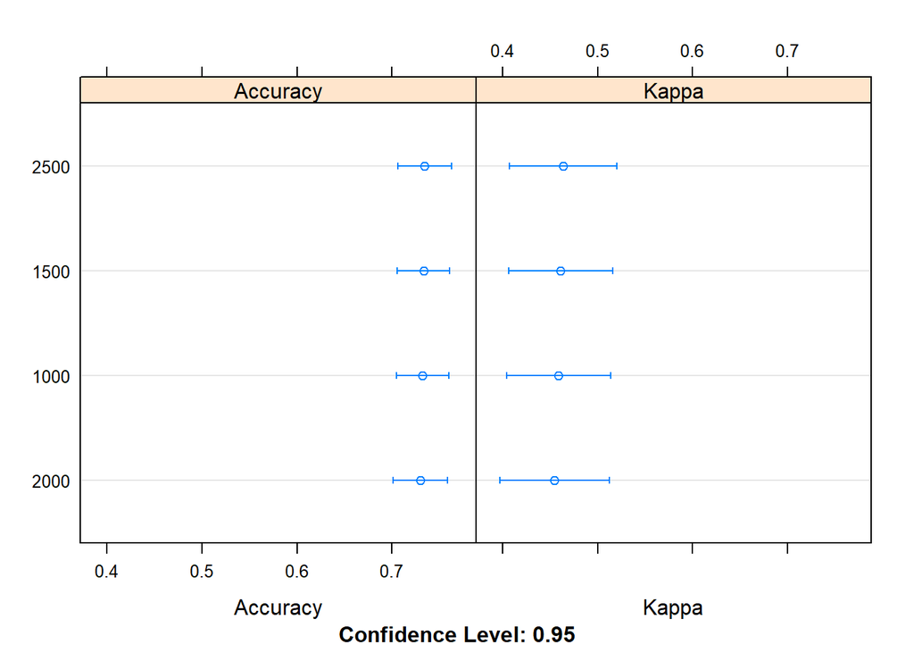

```r
dotplot(results)
```

```r
# Predict
predict(modellist, subTest, type = "prob")
```

```
## $`1000`
##        0     1
## 1  0.067 0.933
## 2  0.077 0.923
## 3  0.182 0.818
## 4  0.001 0.999
## 5  0.002 0.998
## 6  0.034 0.966
## 7  0.182 0.818
## 8  0.348 0.652
## 9  0.051 0.949
## 10 0.299 0.701
## 11 0.283 0.717
## 12 0.100 0.900
## 13 0.011 0.989
```

[output cut: 236 more lines]

```r
predictions<-predict(modellist, subTest)
pred<-predictions$`1000`
confusionMatrix(as.factor(pred),as.factor(Test_pred))
```

```
## Confusion Matrix and Statistics
##
##           Reference
## Prediction  0  1
##          0 27  0
##          1  0 33
##
##                Accuracy : 1
##                  95% CI : (0.9404, 1)
##     No Information Rate : 0.55
##     P-Value [Acc > NIR] : 2.641e-16
##
##                   Kappa : 1
##
##  Mcnemar's Test P-Value : NA
##
##             Sensitivity : 1.00
##             Specificity : 1.00
##          Pos Pred Value : 1.00
##          Neg Pred Value : 1.00
##              Prevalence : 0.45
##          Detection Rate : 0.45
##    Detection Prevalence : 0.45
##       Balanced Accuracy : 1.00
##
##        'Positive' Class : 0
##
```

```r
# Example of Boosting Algorithms: Gradient Boosting Method and C 5.0

control <- trainControl(method="repeatedcv", number=10, repeats=3)
seed <- 7
metric <- "Accuracy"
# C5.0
set.seed(seed)
fit.c50 <- train(HeartAttackRisk ~ ., subTrain, method="C5.0", metric=metric, trControl=control)
# Stochastic Gradient Boosting
set.seed(seed)
fit.gbm <- train(HeartAttackRisk ~ ., subTrain, method="gbm", metric=metric, trControl=control, verbose=FALSE)
# summarize results
boosting_results <- resamples(list(c5.0=fit.c50, gbm=fit.gbm))
summary(boosting_results)
```

```
##
## Call:
## summary.resamples(object = boosting_results)
##
## Models: c5.0, gbm
## Number of resamples: 30
##
## Accuracy
##           Min.   1st Qu.    Median      Mean   3rd Qu.      Max. NA's
## c5.0 0.4800000 0.6770833 0.7291667 0.7393889 0.7979167 0.8750000    0
## gbm  0.5833333 0.6800000 0.7550000 0.7493333 0.7979167 0.9583333    0
##
## Kappa
##             Min.   1st Qu.    Median      Mean   3rd Qu.      Max. NA's
## c5.0 -0.08695652 0.3512744 0.4703933 0.4726174 0.5958133 0.7500000    0
## gbm   0.14893617 0.3527306 0.5128706 0.4931387 0.5943864 0.9166667    0
```

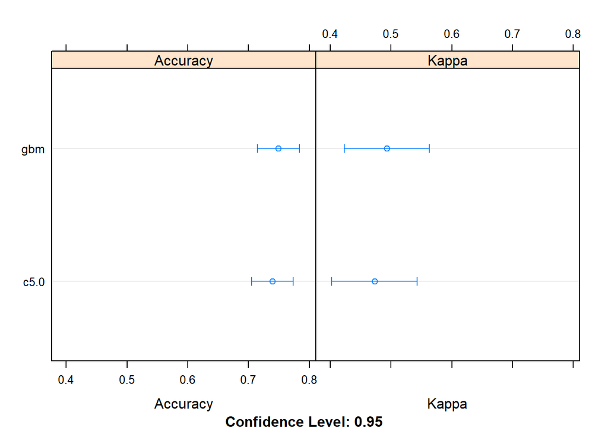

```r
dotplot(boosting_results)
```

```r
# Prediction for C5.0
predict(fit.c50, subTest, type = "prob")
```

```
##    0 1
## 1  0 1
## 2  0 1
## 3  0 1
## 4  0 1
## 5  0 1
## 6  0 1
## 7  1 0
## 8  1 0
## 9  0 1
## 10 1 0
## 11 1 0
## 12 0 1
## 13 0 1
## 14 0 1
```

[output cut: 46 more lines]

```r
predictions<-predict(fit.c50, subTest)
confusionMatrix(as.factor(predictions),as.factor(Test_pred))
```

```
## Confusion Matrix and Statistics
##
##           Reference
## Prediction  0  1
##          0 20 11
##          1  7 22
##
##                Accuracy : 0.7
##                  95% CI : (0.5679, 0.8115)
##     No Information Rate : 0.55
##     P-Value [Acc > NIR] : 0.01268
##
##                   Kappa : 0.402
##
##  Mcnemar's Test P-Value : 0.47950
##
##             Sensitivity : 0.7407
##             Specificity : 0.6667
##          Pos Pred Value : 0.6452
##          Neg Pred Value : 0.7586
##              Prevalence : 0.4500
##          Detection Rate : 0.3333
##    Detection Prevalence : 0.5167
##       Balanced Accuracy : 0.7037
##
##        'Positive' Class : 0
##
```

```r
# Prediction for Gradient Boosting
predict(fit.gbm, subTest, type = "prob")
```

```
##             0          1
## 1  0.23939729 0.76060271
## 2  0.15175495 0.84824505
## 3  0.42759207 0.57240793
## 4  0.11689126 0.88310874
## 5  0.05948642 0.94051358
## 6  0.12918891 0.87081109
## 7  0.39639749 0.60360251
## 8  0.87478007 0.12521993
## 9  0.14456607 0.85543393
## 10 0.91250273 0.08749727
## 11 0.62965862 0.37034138
## 12 0.21483432 0.78516568
## 13 0.10354517 0.89645483
## 14 0.18163456 0.81836544
```

[output cut: 46 more lines]

```r
predictions<-predict(fit.gbm, subTest)
confusionMatrix(as.factor(predictions),as.factor(Test_pred))
```

```
## Confusion Matrix and Statistics
##
##           Reference
## Prediction  0  1
##          0 19  9
##          1  8 24
##
##                Accuracy : 0.7167
##                  95% CI : (0.5856, 0.8255)
##     No Information Rate : 0.55
##     P-Value [Acc > NIR] : 0.006083
##
##                   Kappa : 0.4295
##
##  Mcnemar's Test P-Value : 1.000000
##
##             Sensitivity : 0.7037
##             Specificity : 0.7273
##          Pos Pred Value : 0.6786
##          Neg Pred Value : 0.7500
##              Prevalence : 0.4500
##          Detection Rate : 0.3167
##    Detection Prevalence : 0.4667
##       Balanced Accuracy : 0.7155
##
##        'Positive' Class : 0
##
```

```r
# Example of Bagging : Random Forest and Bagged Cart


# Example of Bagging algorithms
control <- trainControl(method="repeatedcv", number=10, repeats=3)
seed <- 7
metric <- "Accuracy"
# Bagged CART
set.seed(seed)
fit.treebag <- train(HeartAttackRisk ~ ., subTrain, method="treebag", metric=metric, trControl=control)
# Random Forest
set.seed(seed)
fit.rf <- train(HeartAttackRisk ~ ., subTrain, method="rf", metric=metric, trControl=control)
# summarize results
bagging_results <- resamples(list(treebag=fit.treebag, rf=fit.rf))
summary(bagging_results)
```

```
##
## Call:
## summary.resamples(object = bagging_results)
##
## Models: treebag, rf
## Number of resamples: 30
##
## Accuracy
##              Min.   1st Qu.    Median      Mean   3rd Qu.  Max. NA's
## treebag 0.6000000 0.6666667 0.6941667 0.7107778 0.7500000 0.875    0
## rf      0.5833333 0.7083333 0.7500000 0.7425000 0.7916667 0.875    0
##
## Kappa
##              Min.   1st Qu.    Median      Mean   3rd Qu.      Max. NA's
## treebag 0.2038217 0.3141822 0.3815287 0.4153529 0.5085151 0.7464789    0
## rf      0.1836735 0.4084507 0.5033538 0.4797405 0.5818662 0.7500000    0
```

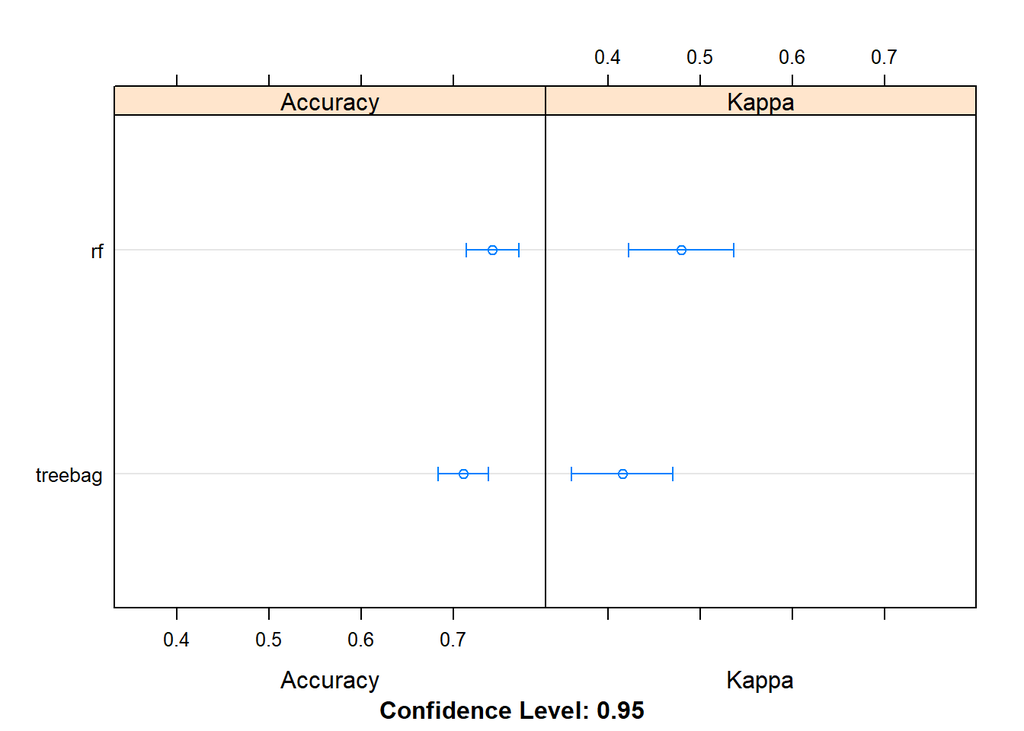

```r
dotplot(bagging_results)
```

```r
# Predictions for Bagged Cart
predict(fit.treebag, subTest, type = "prob")
```

```
##       0    1
## 1  0.04 0.96
## 2  0.20 0.80
## 3  0.48 0.52
## 4  0.08 0.92
## 5  0.00 1.00
## 6  0.08 0.92
## 7  0.32 0.68
## 8  0.92 0.08
## 9  0.12 0.88
## 10 0.96 0.04
## 11 0.80 0.20
## 12 0.32 0.68
## 13 0.00 1.00
## 14 0.32 0.68
```

[output cut: 46 more lines]

```r
predictions<-predict(fit.treebag, subTest)
confusionMatrix(as.factor(predictions),as.factor(Test_pred))
```

```
## Confusion Matrix and Statistics
##
##           Reference
## Prediction  0  1
##          0 19  8
##          1  8 25
##
##                Accuracy : 0.7333
##                  95% CI : (0.6034, 0.8393)
##     No Information Rate : 0.55
##     P-Value [Acc > NIR] : 0.002709
##
##                   Kappa : 0.4613
##
##  Mcnemar's Test P-Value : 1.000000
##
##             Sensitivity : 0.7037
##             Specificity : 0.7576
##          Pos Pred Value : 0.7037
##          Neg Pred Value : 0.7576
##              Prevalence : 0.4500
##          Detection Rate : 0.3167
##    Detection Prevalence : 0.4500
##       Balanced Accuracy : 0.7306
##
##        'Positive' Class : 0
##
```

```r
# Predictions for Random Forest
predict(fit.rf, subTest, type = "prob")
```

```
##        0     1
## 1  0.186 0.814
## 2  0.274 0.726
## 3  0.364 0.636
## 4  0.022 0.978
## 5  0.030 0.970
## 6  0.146 0.854
## 7  0.302 0.698
## 8  0.918 0.082
## 9  0.172 0.828
## 10 0.860 0.140
## 11 0.714 0.286
## 12 0.334 0.666
## 13 0.110 0.890
## 14 0.244 0.756
```

[output cut: 46 more lines]

```r
predictions<-predict(fit.rf, subTest)
confusionMatrix(as.factor(predictions),as.factor(Test_pred))
```

```
## Confusion Matrix and Statistics
##
##           Reference
## Prediction  0  1
##          0 19  8
##          1  8 25
##
##                Accuracy : 0.7333
##                  95% CI : (0.6034, 0.8393)
##     No Information Rate : 0.55
##     P-Value [Acc > NIR] : 0.002709
##
##                   Kappa : 0.4613
##
##  Mcnemar's Test P-Value : 1.000000
##
##             Sensitivity : 0.7037
##             Specificity : 0.7576
##          Pos Pred Value : 0.7037
##          Neg Pred Value : 0.7576
##              Prevalence : 0.4500
##          Detection Rate : 0.3167
##    Detection Prevalence : 0.4500
##       Balanced Accuracy : 0.7306
##
##        'Positive' Class : 0
##
```